# Capstone Notes

Following the submission of my [milestone report](http://rpubs.com/zedleb/230152) (unfinished) I decided to abandon both the *tm* and *qdap* packages and go all in with [tidytext](http://tidytextmining.com/).

My reasons are two-fold  
1. I resonate with the HadleyVerse :)  
2. tidytext is a new package and it might gain me some extra interest in the final project!

### Sampling the data files

This caused me a real headache for the milestone. I did use something along the lines of the code below to read in via a connection and I got my 5% samples. However, I noticed that the number of lines bore little resemblence to the number of words contained in the document and I felt I was getting a skewed sample.

I want to sample in a proportion of the *words* of the datasets - not the lines. I am unsure how to progress this without first reading the lot in…and doing some sort of word count/line (I have code for this)

```r
#http://stackoverflow.com/questions/18705459/how-to-sample-a-specific-proportion-of-lines-from-a-big-file-in-r
n <- 1000
con <- file("text.txt", open = "r") # noticed that "rb" worked for the 'news' file
head <- readLines(con, 1)
sampdat <- readLines(con, n)
k <- n
while (length(curline <- readLines(con, 1))) {
  k <- k + 1
  if (runif(1) < n/k) f
  sampdat[sample(n, 1)] <- curline
}
 # }
close(con)
delaysamp <- read.csv(textConnection(c(head, sampdat)))
```

### Tidytext

Began learning via the [tutorial page](http://tidytextmining.com/tidytext.html)

Love the simplicity of ‘unnest’ which has a tokeniser built in and also removes punctuation and transforms to lower case in one function.

```r
library(dplyr)
library(ggplot2)
library(tidytext)
library(janeaustenr)
library(stringr)

original_books <- austen_books() %>%
  group_by(book) %>%
  mutate(linenumber = row_number(),
         chapter = cumsum(str_detect(text, regex("^chapter [\\divxlc]",
                                                 ignore_case = TRUE)))) %>%
  ungroup()

original_books

tidy_books <- original_books %>%
  unnest_tokens(word, text)

tidy_books # 725054 obs
```

Stopwords are removed by an anti-join with the stop_words dataframe.

```r
data(stop_words)

tidy_books <- tidy_books %>%
  anti_join(stop_words) # 217609 obs
```

Count of words in descending order

```r
tidy_books %>%
  count(word, sort = TRUE)
```

Visualisations with ggplot can be done straightaway

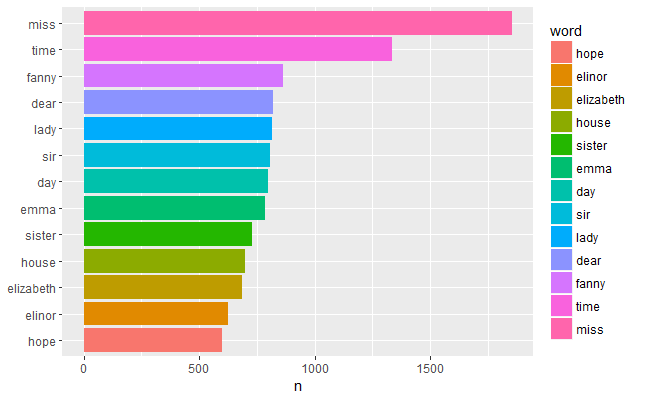

Adding other datasets to enable cross comparisons within a tidy setup.  
First HGWells

```r
library(gutenbergr)
hgwells <- gutenberg_download(c(35, 36, 5230, 159))

tidy_hgwells <- hgwells %>%
  unnest_tokens(word, text) %>%
  anti_join(stop_words)

tidy_hgwells %>%
  count(word, sort = TRUE)
```

Then the Bronte sisters

```r
bronte <- gutenberg_download(c(1260, 768, 969, 9182, 766))

tidy_bronte <- bronte %>%
  unnest_tokens(word, text) %>%
  anti_join(stop_words)

tidy_bronte %>%
  count(word, sort = TRUE)
```

Joining them all together

```r
tidy_both <- bind_rows(
  mutate(tidy_bronte, author = "BrontÃ« Sisters"),
  mutate(tidy_hgwells, author = "H.G. Wells"))
frequency <- tidy_both %>%
  mutate(word = str_extract(word, "[a-z]+")) %>%
  count(author, word) %>%
  rename(other = n) %>%
  inner_join(count(tidy_books, word)) %>%
  rename(Austen = n) %>%
  mutate(other = other / sum(other),
         Austen = Austen / sum(Austen)) %>%
  ungroup()
```

Plotting  
This would be a great exercise on the three different datasets for the Capstone. Just to see the variety of words…

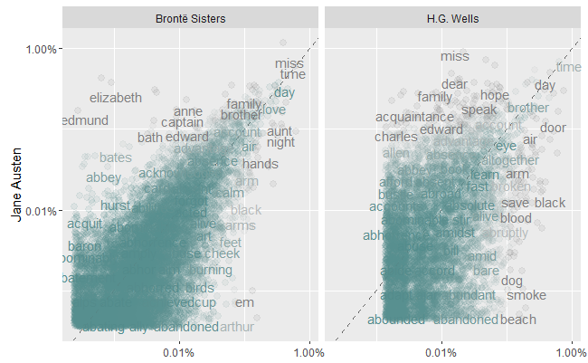

```r
library(scales)
ggplot(frequency, aes(x = other, y = Austen, color = abs(Austen - other))) +
  geom_abline(color = "gray40", lty = 2) +
  geom_jitter(alpha = 0.1, size = 2.5, width = 0.4, height = 0.4) +
  geom_text(aes(label = word), check_overlap = TRUE, vjust = 1.5) +
  scale_x_log10(labels = percent_format()) +
  scale_y_log10(labels = percent_format()) +
  scale_color_gradient(limits = c(0, 0.001), low = "darkslategray4", high = "gray75") +
  facet_wrap(~author, ncol = 2) +
  theme(legend.position="none") +
  labs(y = "Jane Austen", x = NULL)
```

We can perform correlation tests on the differnt texts

```r
cor.test(data = frequency[frequency$author == "BrontÃ« Sisters",],
         ~ other + Austen)
```

```
    Pearson's product-moment correlation

data:  other and Austen
t = 122.51, df = 10620, p-value < 2.2e-16
alternative hypothesis: true correlation is not equal to 0
95 percent confidence interval:
 0.7572592 0.7730237
sample estimates:
      cor
0.7652562
```

```r
cor.test(data = frequency[frequency$author == "H.G. Wells",],
         ~ other + Austen)
```

```
    Pearson's product-moment correlation

data:  other and Austen
t = 36.058, df = 5962, p-value < 2.2e-16
alternative hypothesis: true correlation is not equal to 0
95 percent confidence interval:
 0.4020611 0.4437385
sample estimates:
      cor
0.4231236
```